# Self-Driving Car Engineer Nanodegree - Kang Min Su

## Project: Build a Traffic Sign Recognition Classifier

## Step 0: Load The Data

The original datam used in the project can be found data folder.

```python
# Load pickled data
import pickle

# TODO: Fill this in based on where you saved the training and testing data

training_file = './data/train.p'
validation_file= './data/valid.p'
testing_file =  './data/test.p'

with open(training_file, mode='rb') as f:
    train = pickle.load(f)
with open(validation_file, mode='rb') as f:
    valid = pickle.load(f)
with open(testing_file, mode='rb') as f:
    test = pickle.load(f)

X_train, y_train = train['features'], train['labels']
X_valid, y_valid = valid['features'], valid['labels']
X_test, y_test = test['features'], test['labels']
```

## Step 1: Dataset Summary & Exploration

The pickled data is a dictionary with 4 key/value pairs:

- `'features'` is a 4D array containing raw pixel data of the traffic sign images, (num examples, width, height, channels).
- `'labels'` is a 1D array containing the label/class id of the traffic sign. The file `signnames.csv` contains id -> name mappings for each id.
- `'sizes'` is a list containing tuples, (width, height) representing the original width and height the image.
- `'coords'` is a list containing tuples, (x1, y1, x2, y2) representing coordinates of a bounding box around the sign in the image. **THESE COORDINATES ASSUME THE ORIGINAL IMAGE. THE PICKLED DATA CONTAINS RESIZED VERSIONS (32 by 32) OF THESE IMAGES**

Complete the basic data summary below. Use python, numpy and/or pandas methods to calculate the data summary rather than hard coding the results. For example, the [pandas shape method](http://pandas.pydata.org/pandas-docs/stable/generated/pandas.DataFrame.shape.html) might be useful for calculating some of the summary results.

### Provide a Basic Summary of the Data Set Using Python, Numpy and/or Pandas

```python
import numpy as np

n_train = len(X_train)
n_valid = len(X_valid)
n_test = len(X_test)

image_shape = X_train[0].shape
unique_classes, n_samples = np.unique(y_train,
                                          return_index=False,
                                          return_inverse=False,
                                          return_counts=True)
n_classes = len(unique_classes)

print("Number of training examples =", n_train)
print("Number of validation examples =", n_valid)
print("Number of testing examples =", n_test)
print("Image data shape =", image_shape)
print("Number of classes =", n_classes)
```

```
Number of training examples = 34799
Number of validation examples = 4410
Number of testing examples = 12630
Image data shape = (32, 32, 3)
Number of classes = 43
```

### Include an exploratory visualization of the dataset

Visualize the German Traffic Signs Dataset using the pickled file(s). This is open ended, suggestions include: plotting traffic sign images, plotting the count of each sign, etc.

The [Matplotlib](http://matplotlib.org/) [examples](http://matplotlib.org/examples/index.html) and [gallery](http://matplotlib.org/gallery.html) pages are a great resource for doing visualizations in Python.

**NOTE:** It's recommended you start with something simple first. If you wish to do more, come back to it after you've completed the rest of the sections. It can be interesting to look at the distribution of classes in the training, validation and test set. Is the distribution the same? Are there more examples of some classes than others?

```python
import random
import numpy as np
import matplotlib.pyplot as plt
%matplotlib inline

index = random.randint(0, len(X_train))
image = X_train[index].squeeze()

plt.figure(figsize=(1,1))
plt.imshow(image)
print(y_train[index])
```

[output not shown]

```
18
```

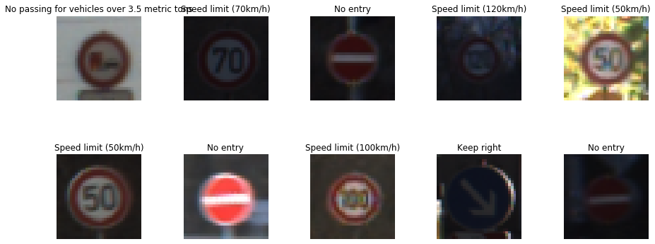

```python
from pandas import read_csv

label_signs = read_csv('./signnames.csv').values[:, 1]  # fetch only sign names

fig, axs = plt.subplots(2,5, figsize=(15, 6))
fig.subplots_adjust(hspace = .5, wspace=.5)
axs = axs.ravel()
for i in range(10):
    index = random.randint(0, len(X_train))
    image = X_train[index]
    axs[i].axis('off')
    axs[i].imshow(image)
    axs[i].set_title(label_signs[y_train[index]])
```

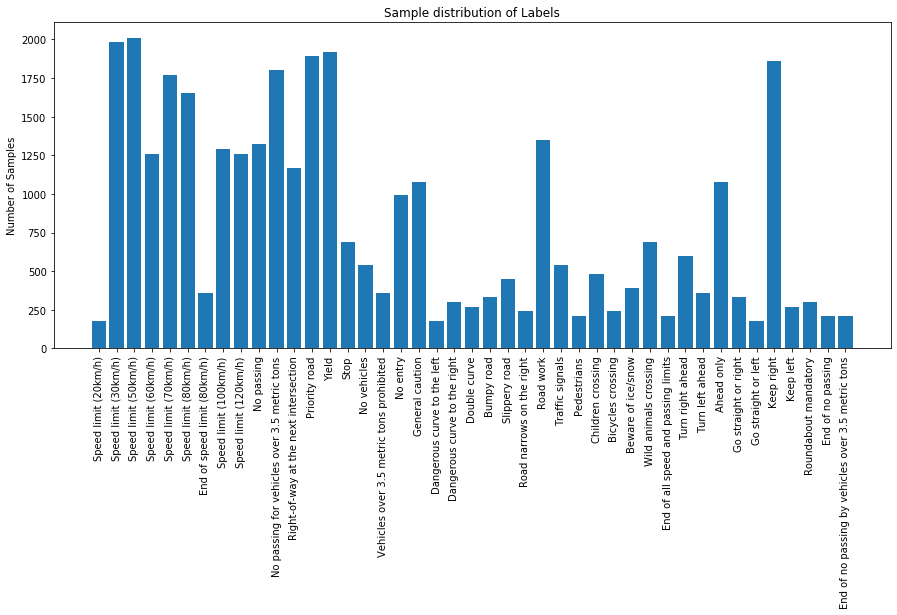

```python
import matplotlib.pyplot as plt

labels_unique = []
for i in range(n_classes):
    labels_unique.append(label_signs[i])

index = random.randint(0, len(X_train))

fig = plt.figure(figsize=(15, 6))
ax = fig.add_subplot(111)
ax.set_title('Sample distribution of Labels')
# ax.set_xlabel('Classes')
ax.set_xticks(np.arange(len(labels_unique)))
ax.set_xticklabels(labels_unique, rotation='vertical')
ax.set_ylabel('Number of Samples')
plt.bar(range(n_classes), n_samples)
plt.show()
```

## Step 2: Design and Test a Model Architecture

Design and implement a deep learning model that learns to recognize traffic signs. Train and test your model on the [German Traffic Sign Dataset](http://benchmark.ini.rub.de/?section=gtsrb&subsection=dataset).

The LeNet-5 implementation shown in the classroom at the end of the CNN lesson is a solid starting point. You'll have to change the number of classes and possibly the preprocessing, but aside from that it's plug and play!

With the LeNet-5 solution from the lecture, you should expect a validation set accuracy of about 0.89. To meet specifications, the validation set accuracy will need to be at least 0.93. It is possible to get an even higher accuracy, but 0.93 is the minimum for a successful project submission.

There are various aspects to consider when thinking about this problem:

- Neural network architecture (is the network over or underfitting?)
- Play around preprocessing techniques (normalization, rgb to grayscale, etc)
- Number of examples per label (some have more than others).
- Generate fake data.

Here is an example of a [published baseline model on this problem](http://yann.lecun.com/exdb/publis/pdf/sermanet-ijcnn-11.pdf). It's not required to be familiar with the approach used in the paper but, it's good practice to try to read papers like these.

### Pre-process the Data Set (normalization, grayscale, etc.)

Minimally, the image data should be normalized so that the data has mean zero and equal variance. For image data, (pixel - 128)/ 128 is a quick way to approximately normalize the data and can be used in this project.

Other pre-processing steps are optional. You can try different techniques to see if it improves performance.

Use the code cell (or multiple code cells, if necessary) to implement the first step of your project.

```python
# Convert to grayscale
def convert_RGB_GRY(data, keepdims):
    input_rgb = data
    input_gry = np.sum(data/3, axis=3, keepdims=keepdims)
    return input_rgb, input_gry

X_train_rgb, X_train_gry = convert_RGB_GRY(X_train, keepdims=True)
X_valid_rgb, X_valid_gry = convert_RGB_GRY(X_valid, keepdims=True)
X_test_rgb, X_test_gry = convert_RGB_GRY(X_test, keepdims=True)

print('RGB shape for train:', X_train_rgb.shape)
print('RGB shape for valid:', X_valid_rgb.shape)
print('RGB shape for test:', X_test_rgb.shape)

print('Grayscale shape for train:', X_train_gry.shape)
print('Grayscale shape for valid:', X_valid_gry.shape)
print('Grayscale shape for test:', X_test_gry.shape)
```

```
RGB shape for train: (34799, 32, 32, 3)
RGB shape for valid: (4410, 32, 32, 3)
RGB shape for test: (12630, 32, 32, 3)
Grayscale shape for train: (34799, 32, 32, 1)
Grayscale shape for valid: (4410, 32, 32, 1)
Grayscale shape for test: (12630, 32, 32, 1)
```

```python
# Replace training, validation and testing variables with grayscale.
X_train = X_train_gry
X_valid = X_valid_gry
X_test = X_test_gry

print('Updated train, test and validation set to gray scale.')
```

```
Updated train, test and validation set to gray scale.
```

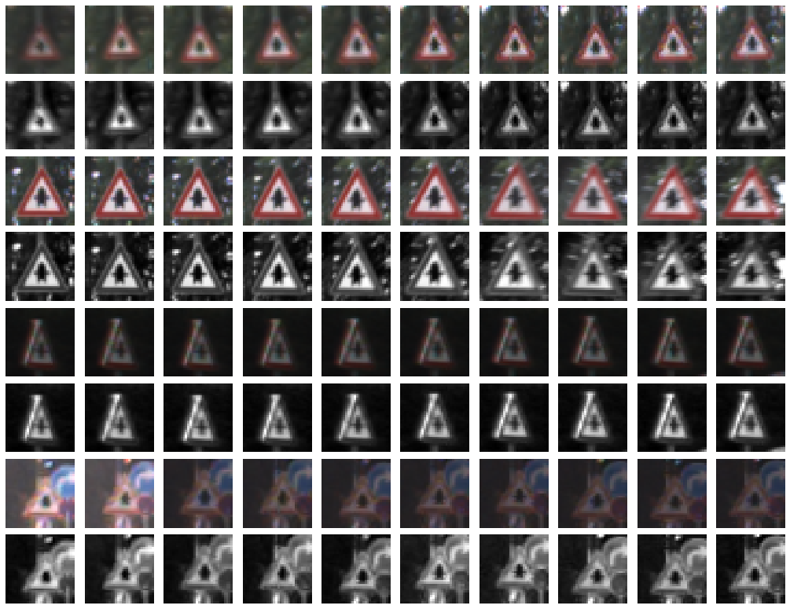

```python
# Visualize rgb vs grayscale
n_rows = 8
n_cols = 10
offset = 9000
fig, axs = plt.subplots(n_rows,n_cols, figsize=(18, 14))
fig.subplots_adjust(hspace = .1, wspace=.001)
axs = axs.ravel()
for j in range(0,n_rows,2):
    for i in range(n_cols):
        index = i + j*n_cols
        image = X_train_rgb[index + offset]
        axs[index].axis('off')
        axs[index].imshow(image)
    for i in range(n_cols):
        index = i + j*n_cols + n_cols
        image = X_train_gry[index + offset - n_cols].squeeze()
        axs[index].axis('off')
        axs[index].imshow(image, cmap='gray')
```

```python
# Normalize the train validation and test dataset
print(np.mean(X_train))
print(np.mean(X_valid))
print(np.mean(X_test))
```

```
82.67758903699634
83.55642737563775
82.14846036120173
```

```python
## Normalize the train, valid and test datasets to (-1,1)
X_train_normalized = (X_train - 128)/128
X_valid_normalized = (X_valid - 128)/128
X_test_normalized = (X_test - 128)/128

print(np.mean(X_train_normalized))
print(np.mean(X_valid_normalized))
print(np.mean(X_test_normalized))
```

```
-0.35408133564846583
-0.3472154111278294
-0.3582151534281105
```

```
Original shape: (34799, 32, 32, 1)
Normalized shape: (34799, 32, 32, 1)
```

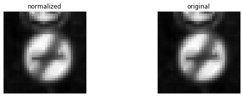

```python
print("Original shape:", X_train.shape)
print("Normalized shape:", X_train_normalized.shape)
fig, axs = plt.subplots(1,2, figsize=(10, 3))
axs = axs.ravel()

axs[0].axis('off')
axs[0].set_title('normalized')
axs[0].imshow(X_train_normalized[0].squeeze(), cmap='gray')

axs[1].axis('off')
axs[1].set_title('original')
axs[1].imshow(X_train[0].squeeze(), cmap='gray')
```

```python
#Set values in train, validation and test set to normalized values.
X_train = X_train_normalized
X_valid = X_valid_normalized
X_test = X_test_normalized
```

```python
# Shuffle the training set.
from sklearn.utils import shuffle

X_train, y_train = shuffle(X_train, y_train)

print('Data is now shuffuled for intial input. Here`s top 500 values represented via their labels.')
print(y_train[0:500])
```

[output not shown]

### Model Architecture - LeNet

Original ConvNet Architecturre.

[figure not shown]

- For this Project we have modified the architecture based on the following paper by Prof. Yann LeCun. http://yann.lecun.com/exdb/publis/pdf/sermanet-ijcnn-11.pdf

### The Modified Model Architecture

##### Input

This LeNet architecture accepts a 32x32xC image as input, where C is the number of color channels. For our case after preproceessing, initally C would have been 3 due to three layers of RGB Color channel but now as images are in left gray color channel, therefore C = 1.

##### Activation Function used:

ReLU

##### Number of Epoch's and Batch Size after Experimentation.

60 - EPOCH and 100 - BATCH

##### Architecture

**Activation** Apply chosen activation function.

**2x2 Max Pooling** This step is refered to as sub sampling in the paper refered above. The output shape should be 14x14x6.

**Layer 2: 5x5 Convolution** The output shape should be 10x10x16.

**Activation** Apply chosen activation function.

**2x2 Max Pooling** The output shape should be 5x5x16.

**Layer 3 - 5x5 Convolution** The output shape should be 1x1x400.

**Activation** Apply chosen activation function.

**Flatten & Merge** Flatten the output shape of the Max Poling and Convlution layer such that it's 1D output of 800. The easiest way to do is by using `tf.contrib.layers.flatten`.

**Dropout** Drop and keep probabilties.

**Layer 5 - Fully Connected (Logits).** This should result in 43 outputs as there are 43 total classes.

##### Output (Logits)

```python
import tensorflow as tf

EPOCHS = 60
BATCH_SIZE = 100

print('epochs and batch size is set.')
```

```
epochs and batch size is set.
```

```python
from tensorflow.contrib.layers import flatten

def LeNet(x):
    # Hyperparameters
    mu = 0
    sigma = 0.1

    # Layer 1: Convolutional. Input = 32x32x1. Output = 28x28x6.
    W1 = tf.Variable(tf.truncated_normal(shape=(5, 5, 1, 6), mean = mu, stddev = sigma))
    x = tf.nn.conv2d(x, W1, strides=[1, 1, 1, 1], padding='VALID')
    b1 = tf.Variable(tf.zeros(6), name="b1")
    x = tf.nn.bias_add(x, b1)
    print("1st Layer shape:",x.get_shape())

    # Activation.
    x = tf.nn.relu(x)

    # Max Pooling. Input = 28x28x6. Output = 14x14x6.
    x = tf.nn.max_pool(x, ksize=[1, 2, 2, 1], strides=[1, 2, 2, 1], padding='VALID', name='conv1')
    x1 = x
    print("1st Layer after max pooling shape:",x1.get_shape())

    # Layer 2: Convolutional. Output = 10x10x16.
    W2 = tf.Variable(tf.truncated_normal(shape=(5, 5, 6, 16), mean = mu, stddev = sigma))
    x = tf.nn.conv2d(x, W2, strides=[1, 1, 1, 1], padding='VALID')
    b2 = tf.Variable(tf.zeros(16), name="b2")
    x = tf.nn.bias_add(x, b2)
    print("2nd Layer shape:",x.get_shape())

    # Activation.
    x = tf.nn.relu(x)

    # Max Pooling. Input = 10x10x16. Output = 5x5x16.
    x = tf.nn.max_pool(x, ksize=[1, 2, 2, 1], strides=[1, 2, 2, 1], padding='VALID', name='conv2')
    x2 = x
    print("2nd Layer after max pooling shape:",x2.get_shape())

    # Layer 3: Convolutional. Output = 1x1x400.
    W3 = tf.Variable(tf.truncated_normal(shape=(5, 5, 16, 400), mean = mu, stddev = sigma))
    x = tf.nn.conv2d(x, W3, strides=[1, 1, 1, 1], padding='VALID')
    b3 = tf.Variable(tf.zeros(400), name="b3")
    x = tf.nn.bias_add(x, b3)
    print("3rd Layer shape:",x.get_shape())

    # Activation.
    x = tf.nn.relu(x)
    x3 = x

    # Layer 4: Flatten. Input = 5x5x16. Output = 400.
    flat_layer2 = flatten(x2)
    print("After Flattening 2nd Layer post max pooling shape:",flat_layer2.get_shape())

    # Flatten x. Input = 1x1x400. Output = 400.
    flat_layer3 = flatten(x3)
    print("After Flattening 3rd Layer after activation shape:",flat_layer3.get_shape())

    # Concat layer2flat and x. Input = 400 + 400. Output = 800
    x = tf.concat([flat_layer3, flat_layer2], 1)
    print("After Concatenating Flat Layers shape:",x.get_shape())

    # Dropout
    x = tf.nn.dropout(x, keep_prob)
    print("Dropout Layer shape:",x.get_shape())

    # TODO: Layer 4: Fully Connected. Input = 800. Output = 43.
    W4 = tf.Variable(tf.truncated_normal(shape=(800, 43), mean = mu, stddev = sigma))
    b4 = tf.Variable(tf.zeros(43), name="b4")
    logits = tf.add(tf.matmul(x, W4), b4)
    print("Logits shape:",logits.get_shape())

    return logits

print('done')
```

```
done
```

### Features and Labels

x is a placeholder for a batch of input images. y is a placeholder for a batch of output labels.

```python
x = tf.placeholder(tf.float32, (None, 32, 32, 1))
y = tf.placeholder(tf.int32, (None))
x_final_test = tf.placeholder(tf.float32, (None, 32, 32, 1))
x_final_graph = tf.placeholder(tf.float32, (None, 32, 32, 1))
keep_prob = tf.placeholder(tf.float32) # probability to keep units
one_hot_y = tf.one_hot(y, 43)
```

### Train and Validate the Model

A validation set can be used to assess how well the model is performing. A low accuracy on the training and validation sets imply underfitting. A high accuracy on the training set but low accuracy on the validation set implies overfitting.

#### Training Pipeline

```python
rate = 0.0009

logits = LeNet(x)
cross_entropy = tf.nn.softmax_cross_entropy_with_logits(labels=one_hot_y, logits=logits)
loss_operation = tf.reduce_mean(cross_entropy)
optimizer = tf.train.AdamOptimizer(learning_rate = rate)
training_operation = optimizer.minimize(loss_operation)
```

```
1st Layer shape: (?, 28, 28, 6)
1st Layer after max pooling shape: (?, 14, 14, 6)
2nd Layer shape: (?, 10, 10, 16)
2nd Layer after max pooling shape: (?, 5, 5, 16)
3rd Layer shape: (?, 1, 1, 400)
After Flattening 2nd Layer post max pooling shape: (?, 400)
After Flattening 3rd Layer after activation shape: (?, 400)
After Concatenating Flat Layers shape: (?, 800)
Dropout Layer shape: (?, 800)
Logits shape: (?, 43)
```

#### Model Evaluation

```python
correct_prediction = tf.equal(tf.argmax(logits, 1), tf.argmax(one_hot_y, 1))
accuracy_operation = tf.reduce_mean(tf.cast(correct_prediction, tf.float32))
saver = tf.train.Saver()

def evaluate(X_data, y_data):
    num_examples = len(X_data)
    total_accuracy = 0
    sess = tf.get_default_session()
    for offset in range(0, num_examples, BATCH_SIZE):
        batch_x, batch_y = X_data[offset:offset+BATCH_SIZE], y_data[offset:offset+BATCH_SIZE]
        accuracy = sess.run(accuracy_operation, feed_dict={x: batch_x, y: batch_y, keep_prob: 1.0})
        total_accuracy += (accuracy * len(batch_x))
    return total_accuracy / num_examples
```

#### Train the Model

- Run the training data through the training pipeline to train the model.
- Before each epoch, shuffle the training set.
- After each epoch, measure the loss and accuracy of the validation set.
- Save the model after training.

```python
with tf.Session() as sess:
    sess.run(tf.global_variables_initializer())
    num_examples = len(X_train)

    print("Training...")
    print()
    for i in range(EPOCHS):
        X_train, y_train = shuffle(X_train, y_train)
        for offset in range(0, num_examples, BATCH_SIZE):
            end = offset + BATCH_SIZE
            batch_x, batch_y = X_train[offset:end], y_train[offset:end]
            sess.run(training_operation, feed_dict={x: batch_x, y: batch_y, keep_prob: 0.5})

        valid_acc = evaluate(X_valid, y_valid)
        print("EPOCH {} ...".format(i+1))
        print("Validation Accuracy = {:.3f}".format(valid_acc))
        print()

    saver.save(sess, 'lenet')
    print("Model saved")
```

```
Training...

EPOCH 1 ...
Validation Accuracy = 0.797

EPOCH 2 ...
Validation Accuracy = 0.877

EPOCH 3 ...
Validation Accuracy = 0.903

EPOCH 4 ...
Validation Accuracy = 0.912

EPOCH 5 ...
Validation Accuracy = 0.919

EPOCH 6 ...
Validation Accuracy = 0.917

EPOCH 7 ...
Validation Accuracy = 0.922

EPOCH 8 ...
Validation Accuracy = 0.933

EPOCH 9 ...
Validation Accuracy = 0.943

EPOCH 10 ...
Validation Accuracy = 0.933

EPOCH 11 ...
Validation Accuracy = 0.926

EPOCH 12 ...
Validation Accuracy = 0.937

EPOCH 13 ...
Validation Accuracy = 0.940
```

[output cut: 128 more lines]

```
Validation Accuracy = 0.954

EPOCH 57 ...
Validation Accuracy = 0.959

EPOCH 58 ...
Validation Accuracy = 0.952

EPOCH 59 ...
Validation Accuracy = 0.949

EPOCH 60 ...
Validation Accuracy = 0.946

Model saved
```

#### Evaluate the Model

Evaluate the performance of the model on the test set. This is only done once!

Note: Dont touch this until you are completely satisfied with your model. If you were to measure the performance of your trained model on the test set, then improve your model, and then measure the performance of your model on the test set again, that would invalidate your test results. You wouldn't get a true measure of how well your model would perform against real data.

```python
with tf.Session() as sess:
    saver.restore(sess, tf.train.latest_checkpoint('.'))

    test_accuracy = evaluate(X_test, y_test)
    print("Test Accuracy = {:.3f}".format(test_accuracy))
```

```
INFO:tensorflow:Restoring parameters from .\lenet
Test Accuracy = 0.941
```

## Step 3: Test a Model on New Images

To give yourself more insight into how your model is working, download at least five pictures of German traffic signs from the web and use your model to predict the traffic sign type.

You may find `signnames.csv` useful as it contains mappings from the class id (integer) to the actual sign name.

### Load and Output the Images

```python
import matplotlib.pyplot as plt
%matplotlib inline

import tensorflow as tf
import numpy as np
import cv2

#reading in an image
import glob
import pandas as pd
import matplotlib.image as mpimg
```

```
Input Image 0 (32, 32, 3)
Input Image 1 (32, 32, 3)
Input Image 2 (32, 32, 3)
Input Image 3 (32, 32, 3)
Input Image 4 (32, 32, 3)
Input Image 5 (32, 32, 3)
After Processing Image: (6, 32, 32, 1)
```

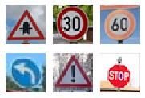

```python
X_final_test = []
X_final_test_name = []

fig, axs = plt.subplots(2,3, figsize=(3, 2))
fig.subplots_adjust(hspace = .2, wspace=.2)
axs = axs.ravel()

def pipeline(file):
    global X_final_test
    my_images = []
    for i, img in enumerate(glob.glob(file)):
        X_final_test_name.append(img)
        image = cv2.imread(img)
        print('Input Image '+ str(i) + ' ' + str(image.shape))
        axs[i].axis('off')
        axs[i].imshow(cv2.cvtColor(image, cv2.COLOR_BGR2RGB))
        my_images.append(image)
    my_images = np.asarray(my_images)
    my_images_gry = np.sum(my_images/3, axis=3, keepdims=True)
    processed_image = (my_images_gry - 128)/128
    print('After Processing Image: ' + str(processed_image.shape))

    return processed_image

X_final_test = pipeline('./test_images/*.png')
X_final_graph = X_final_test
```

```
INFO:tensorflow:Restoring parameters from ./lenet
```

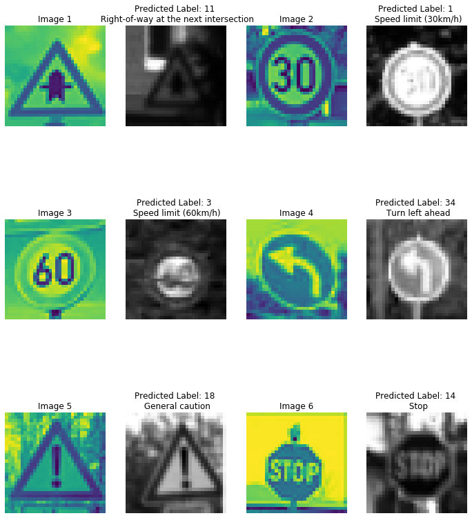

```python
softmax_logits = tf.nn.softmax(logits)
top_k = tf.nn.top_k(softmax_logits, k=3)


with tf.Session() as sess:
    sess.run(tf.global_variables_initializer())
    saver = tf.train.import_meta_graph('./lenet.meta')
    saver.restore(sess, "./lenet")
    my_softmax_logits = sess.run(softmax_logits, feed_dict={x: X_final_test, keep_prob: 1.0})
    my_top_k = sess.run(top_k, feed_dict={x: X_final_test, keep_prob: 1.0})


    fig, axs = plt.subplots(3,4, figsize=(12, 14))
    fig.subplots_adjust(hspace = .4, wspace=.2)
    axs = axs.ravel()

    for i, image in enumerate(X_final_test):
        axs[2*i].axis('off')
        axs[2*i].imshow(image.reshape((32,32)))
        axs[2*i].set_title('Image '+ str(i + 1))
        pred_label = my_top_k[1][i][0]
        index = np.argwhere(y_valid == pred_label)[0]
        axs[2*i+1].axis('off')
        axs[2*i+1].imshow(X_valid[index].squeeze(), cmap='gray')
        axs[2*i+1].set_title('Predicted Label: {} \n {}'.format(pred_label, label_signs[pred_label]))
```

### Analyze Performance

```python
with tf.Session() as sess:
    saver.restore(sess, tf.train.latest_checkpoint('.'))
    y_final_test = [14,1,11,34,3,18]
    test_accuracy = evaluate(X_final_test, y_final_test)
    print("Test Accuracy = {:.0f}%".format(test_accuracy*100))
```

```
INFO:tensorflow:Restoring parameters from .\lenet
Test Accuracy = 33%
```

### Output Top 5 Softmax Probabilities For Each Image Found on the Web

For each of the new images, print out the model's softmax probabilities to show the **certainty** of the model's predictions (limit the output to the top 5 probabilities for each image). [`tf.nn.top_k`](https://www.tensorflow.org/versions/r0.12/api_docs/python/nn.html#top_k) could prove helpful here.

The example below demonstrates how tf.nn.top_k can be used to find the top k predictions for each image.

`tf.nn.top_k` will return the values and indices (class ids) of the top k predictions. So if k=3, for each sign, it'll return the 3 largest probabilities (out of a possible 43) and the correspoding class ids.

Take this numpy array as an example. The values in the array represent predictions. The array contains softmax probabilities for five candidate images with six possible classes. `tf.nn.top_k` is used to choose the three classes with the highest probability:

```
# (5, 6) array
a = np.array([[ 0.24879643,  0.07032244,  0.12641572,  0.34763842,  0.07893497,
         0.12789202],
       [ 0.28086119,  0.27569815,  0.08594638,  0.0178669 ,  0.18063401,
         0.15899337],
       [ 0.26076848,  0.23664738,  0.08020603,  0.07001922,  0.1134371 ,
         0.23892179],
       [ 0.11943333,  0.29198961,  0.02605103,  0.26234032,  0.1351348 ,
         0.16505091],
       [ 0.09561176,  0.34396535,  0.0643941 ,  0.16240774,  0.24206137,
         0.09155967]])
```

Running it through `sess.run(tf.nn.top_k(tf.constant(a), k=3))` produces:

```
TopKV2(values=array([[ 0.34763842,  0.24879643,  0.12789202],
       [ 0.28086119,  0.27569815,  0.18063401],
       [ 0.26076848,  0.23892179,  0.23664738],
       [ 0.29198961,  0.26234032,  0.16505091],
       [ 0.34396535,  0.24206137,  0.16240774]]), indices=array([[3, 0, 5],
       [0, 1, 4],
       [0, 5, 1],
       [1, 3, 5],
       [1, 4, 3]], dtype=int32))
```

Looking just at the first row we get `[ 0.34763842, 0.24879643, 0.12789202]`, you can confirm these are the 3 largest probabilities in `a`. You'll also notice `[3, 0, 5]` are the corresponding indices.

```python
### Print out the top five softmax probabilities for the predictions on the German traffic sign images found on the web.
### Feel free to use as many code cells as needed.

with tf.Session() as sess:
    softmax = tf.nn.softmax(my_softmax_logits)
    top5 = sess.run(tf.nn.top_k(softmax, k=5))
    for x in range(len(X_final_test)):
        print("File Name: [ '{0}' ]".format(X_final_test_name[x]))
        for y in range(5):
            print("{:s}: {:.8f}".format(label_signs[top5[1][x][y]], top5[0][x][y]))
        print('\n')
```

```
File Name: [ './test_images\image1.png' ]
Right-of-way at the next intersection: 0.06078678
Speed limit (20km/h): 0.02236221
Speed limit (30km/h): 0.02236221
Speed limit (50km/h): 0.02236221
Speed limit (60km/h): 0.02236221


File Name: [ './test_images\image2.png' ]
Speed limit (30km/h): 0.06078678
Speed limit (20km/h): 0.02236221
Speed limit (50km/h): 0.02236221
Speed limit (60km/h): 0.02236221
Speed limit (70km/h): 0.02236221


File Name: [ './test_images\image3.png' ]
Speed limit (60km/h): 0.06078678
Speed limit (20km/h): 0.02236221
Speed limit (30km/h): 0.02236221
Speed limit (50km/h): 0.02236221
Speed limit (70km/h): 0.02236221


File Name: [ './test_images\image4.png' ]
Turn left ahead: 0.06078678
Speed limit (20km/h): 0.02236221
Speed limit (30km/h): 0.02236221
Speed limit (50km/h): 0.02236221
Speed limit (60km/h): 0.02236221


File Name: [ './test_images\image5.png' ]
General caution: 0.06078678
Speed limit (20km/h): 0.02236221
Speed limit (30km/h): 0.02236221
Speed limit (50km/h): 0.02236221
Speed limit (60km/h): 0.02236221


File Name: [ './test_images\image6.png' ]
Stop: 0.06067844
No entry: 0.02240535
End of no passing: 0.02236381
End of no passing by vehicles over 3.5 metric tons: 0.02236381
Speed limit (20km/h): 0.02236381
```

### Project Writeup

Once you have completed the code implementation, document your results in a project writeup using this [template](https://github.com/udacity/CarND-Traffic-Sign-Classifier-Project/blob/master/writeup_template.md) as a guide. The writeup can be in a markdown or pdf file.